# Machine Learning in Classifying Dumbbell Lifting

## Introduction

In physical training, it is important to identify false from correct poses. A study is carried with a goal to identify correct dumbbell lifting activities and its incorrect versions. There are six males in the study and they were attached with sensors to arms, forearms, belt, and their dumbbell. Then they repeatedly simulated one correct dumbbell lifting and four other false versions classified as:

- Class A: exactly according to the specification
- Class B: throwing elbows to the front
- Class C: lifting the dumbbell only halfway
- Class D: lowering the dumbbell only halfway
- Class E: throwing the hip to the front

The purpose of this paper is to build a model to detect and labels dumbbell lifting activites. The model is to be built from a data set called training data which contains the data provided by the four sensors attached to six subjects. Then there is testing data serving as a validation of the model.

## Model of Choice

The purpose of this paper is to classify correct dumbbell lifting from its other four false versions. This is a problem of classification on variable with five levels of factors: A, B, C, D, E.

The Gradient Boosting Machines (gbm) shall be used to train a predicting model. This model is chosen because it can support classification trees, which is one of the best algorithm in dealing with classification problems. Furthermore, it supports up to 1024 factor levels.

## Data Processing

Read in training and testing dataset:

```r
training <- read.csv(url("https://d396qusza40orc.cloudfront.net/predmachlearn/pml-training.csv"))
testing <- read.csv(url("https://d396qusza40orc.cloudfront.net/predmachlearn/pml-testing.csv"))
```

The outcomes to which the model is going to be trained to classify are stored in the variable classe:

```r
unique(training$classe)
```

```
## [1] "A" "B" "C" "D" "E"
```

Such that class A labels correct dumbbell lifting while the other classes are false versions, corresponding the the five classes defined in the introduction.

#### The variables of choice

The GBM model is going to be applied to train a model of classification. But the training data is enormous with 19,622 observations and 160 variables (see the structure of the training data in the Appendix). Apply the GBM to this original enormous data is not at all feasible; its dimension is subjected to be reduced.

Also from structure of the training data in the Appendix, there are many variables with many NA values or do not contain values at all. Such variables are useless for the purpose of training so they should be removed. Moreover, the first seven variables contain no informative data about the action of lifting dumbbells collected from the sensors. Thus they are not useful in classifying dumbbell lifting activities and thus shall be removed as well.

```r
# Remove variables containg too many NA and/ore empty variables
training1 <- training
training1 <- apply(training1, 2, function(x) gsub("^$|^ $", NA, x))
NAamount <- apply(training1, 2, function(x) sum(is.na(x)))
NAamount <- as.data.frame(NAamount)
NAamount <- as.character(NAamount$NAamount)
NAIndex <- grep("0", NAamount)
training1 <- as.data.frame(training1)
training1 <- training1[, NAIndex]
# Removed the first seven variables
training1 <- training1[, -c(1:7)]
#Set variables to their proper data type
classe <- training1[, 53]
training1 <- training1[, 1:52]
training1 <- apply(training1, 2, function(x) as.numeric(x))
training1 <- as.data.frame(training1)
classe <- as.data.frame(as.factor(classe))
training1 <- cbind(training1, classe)
colnames(training1)[53] <- "classe"
```

Now the training dataset is in a good shape in that all of them contain values that might become good predictors. However, there are still too many variables remained. Therefore, let’s check the correlation between them all first.

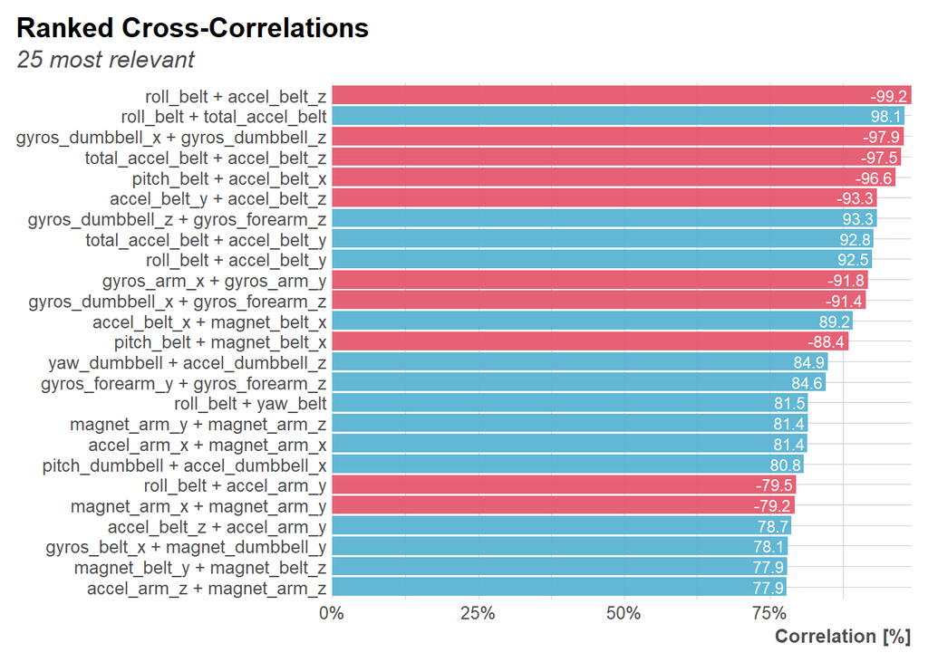

```r
library(lares)
corr_cross(training1)
```

Let’s understand the meaning of the variables in the data set first.

There are sensors attached to the participants’ arm, forearm, belt, and their dumbbell. Each sensor measures the roll, pitch, and yaw of the participants’ body parts and their dumbbell. These are the original measurements. Other measurements are derived from them that are total_acceleration and gyro, acceleration, and magnet in x, y, z axes.

```r
removedVar <- grep("accel|magnet|gyros", names(training1))
remainedVar <- names(training1)[-removedVar]
training1 <- training1[, remainedVar]
```

The remaining variables in the training data is:

```r
str(training1)
```

```
## 'data.frame':    19622 obs. of  13 variables:
##  $ roll_belt     : num  1.41 1.41 1.42 1.48 1.48 1.45 1.42 1.42 1.43 1.45 ...
##  $ pitch_belt    : num  8.07 8.07 8.07 8.05 8.07 8.06 8.09 8.13 8.16 8.17 ...
##  $ yaw_belt      : num  -94.4 -94.4 -94.4 -94.4 -94.4 -94.4 -94.4 -94.4 -94.4 -94.4 ...
##  $ roll_arm      : num  -128 -128 -128 -128 -128 -128 -128 -128 -128 -128 ...
##  $ pitch_arm     : num  22.5 22.5 22.5 22.1 22.1 22 21.9 21.8 21.7 21.6 ...
##  $ yaw_arm       : num  -161 -161 -161 -161 -161 -161 -161 -161 -161 -161 ...
##  $ roll_dumbbell : num  13.1 13.1 12.9 13.4 13.4 ...
##  $ pitch_dumbbell: num  -70.5 -70.6 -70.3 -70.4 -70.4 ...
##  $ yaw_dumbbell  : num  -84.9 -84.7 -85.1 -84.9 -84.9 ...
##  $ roll_forearm  : num  28.4 28.3 28.3 28.1 28 27.9 27.9 27.8 27.7 27.7 ...
##  $ pitch_forearm : num  -63.9 -63.9 -63.9 -63.9 -63.9 -63.9 -63.9 -63.8 -63.8 -63.8 ...
##  $ yaw_forearm   : num  -153 -153 -152 -152 -152 -152 -152 -152 -152 -152 ...
##  $ classe        : Factor w/ 5 levels "A","B","C","D",..: 1 1 1 1 1 1 1 1 1 1 ...
```

### Model Training

To get out of sample error, the training data is spli into training data containing 75% of the original training data and a testing data containing the rest 25%. Let’s train a model on it.

```r
library(caret)
inTrain <- createDataPartition(training1$classe, p=0.75, list=F)
trainData <- training1[inTrain, ]
testData <- training1[-inTrain, ]
modFit <- train(classe ~., data=trainData, method="gbm", verbose = F )
modFit
```

```
## Stochastic Gradient Boosting
##
## 14718 samples
##    12 predictor
##     5 classes: 'A', 'B', 'C', 'D', 'E'
##
## No pre-processing
## Resampling: Bootstrapped (25 reps)
## Summary of sample sizes: 14718, 14718, 14718, 14718, 14718, 14718, ...
## Resampling results across tuning parameters:
##
##   interaction.depth  n.trees  Accuracy   Kappa
##   1                   50      0.6787765  0.5922480
##   1                  100      0.7390982  0.6704279
##   1                  150      0.7654079  0.7037744
##   2                   50      0.7911804  0.7364297
##   2                  100      0.8527386  0.8141376
##   2                  150      0.8814900  0.8503473
##   3                   50      0.8509401  0.8118064
##   3                  100      0.9017553  0.8758776
##   3                  150      0.9250822  0.9053063
##
## Tuning parameter 'shrinkage' was held constant at a value of 0.1
##
## Tuning parameter 'n.minobsinnode' was held constant at a value of 10
## Accuracy was used to select the optimal model using the largest value.
## The final values used for the model were n.trees = 150, interaction.depth =
##  3, shrinkage = 0.1 and n.minobsinnode = 10.
```

#### Cross-Validataion - The expected out of sample error

Let’s cross-validate the train model by applying it to the testData data.

```r
library(caret)
prediction1 <- predict(modFit, newdata=testData[, -13])
confusionMatrix(prediction1, testData$classe)
```

```
## Confusion Matrix and Statistics
##
##           Reference
## Prediction    A    B    C    D    E
##          A 1332   35    5    0    3
##          B   32  856   45   11   15
##          C   15   41  780   19   15
##          D   12   13   22  768   28
##          E    4    4    3    6  840
##
## Overall Statistics
##
##                Accuracy : 0.9331
##                  95% CI : (0.9258, 0.94)
##     No Information Rate : 0.2845
##     P-Value [Acc > NIR] : < 2.2e-16
##
##                   Kappa : 0.9155
##
##  Mcnemar's Test P-Value : 1.187e-06
##
## Statistics by Class:
##
##                      Class: A Class: B Class: C Class: D Class: E
## Sensitivity            0.9548   0.9020   0.9123   0.9552   0.9323
## Specificity            0.9877   0.9740   0.9778   0.9817   0.9958
## Pos Pred Value         0.9687   0.8926   0.8966   0.9110   0.9802
## Neg Pred Value         0.9821   0.9764   0.9814   0.9911   0.9849
## Prevalence             0.2845   0.1935   0.1743   0.1639   0.1837
## Detection Rate         0.2716   0.1746   0.1591   0.1566   0.1713
## Detection Prevalence   0.2804   0.1956   0.1774   0.1719   0.1748
## Balanced Accuracy      0.9713   0.9380   0.9450   0.9685   0.9640
```

## Appendix

The structure of the original training data set:

```r
str(training)
```

```
## 'data.frame':    19622 obs. of  160 variables:
##  $ X                       : int  1 2 3 4 5 6 7 8 9 10 ...
##  $ user_name               : chr  "carlitos" "carlitos" "carlitos" "carlitos" ...
##  $ raw_timestamp_part_1    : int  1323084231 1323084231 1323084231 1323084232 1323084232 1323084232 1323084232 1323084232 1323084232 1323084232 ...
##  $ raw_timestamp_part_2    : int  788290 808298 820366 120339 196328 304277 368296 440390 484323 484434 ...
##  $ cvtd_timestamp          : chr  "05/12/2011 11:23" "05/12/2011 11:23" "05/12/2011 11:23" "05/12/2011 11:23" ...
##  $ new_window              : chr  "no" "no" "no" "no" ...
##  $ num_window              : int  11 11 11 12 12 12 12 12 12 12 ...
##  $ roll_belt               : num  1.41 1.41 1.42 1.48 1.48 1.45 1.42 1.42 1.43 1.45 ...
##  $ pitch_belt              : num  8.07 8.07 8.07 8.05 8.07 8.06 8.09 8.13 8.16 8.17 ...
##  $ yaw_belt                : num  -94.4 -94.4 -94.4 -94.4 -94.4 -94.4 -94.4 -94.4 -94.4 -94.4 ...
##  $ total_accel_belt        : int  3 3 3 3 3 3 3 3 3 3 ...
##  $ kurtosis_roll_belt      : chr  "" "" "" "" ...
##  $ kurtosis_picth_belt     : chr  "" "" "" "" ...
##  $ kurtosis_yaw_belt       : chr  "" "" "" "" ...
```

[output cut: 86 more lines]